# Prediction Assignment - Human Activity Recognition

Ivan

April 24, 2017

## Preface

Thank you for taking your time to review my assignment. I hope you are enjoying the course as well. I really appreciate if you could feedback to me if there is any mistakes or suggestions for this assignment.

## Introduction

Using devices such as Jawbone Up, Nike FuelBand, and Fitbit is common nowadays where people normally use it to quantify how much they do a particular activity. However, they rarely quantify how well they do it.

In this study, data from accelerometers on the belt, forearm, arm, and dumbell of 6 participants are analysed to study the quality of activity execution. They were asked to perform barbell lifts correctly and incorrectly in 5 different ways. See [Weight Lifting Exercise Dataset](http://groupware.les.inf.puc-rio.br/har) for more information.

## Load required libraries

First of all, let’s load a few essential libraries that will aid us in further analysis of this study.

```r
library(gridExtra)      # for visualization
library(ggplot2)        # for visualization
library(FSelector)      # for features selection
library(randomForest)   # for model fitting
```

## Load dataset

`training` data and `testing` data are loaded respectively.

```r
training <- read.csv("pml-training.csv")
testing <- read.csv("pml-testing.csv")
```

## Exploratory analysis

```r
summary(training$classe)
```

```
##    A    B    C    D    E
## 5580 3797 3422 3216 3607
```

Looking at the `training` data, the distribution of target variable `classe` shows that specified execution `A` are performed mostly. Whereas, the other 4 `classe`, namely `B`, `C`, `D` and `E` show less occurences than `A`.

```r
length(which(apply(training,2,function(x){anyNA(x)|any(x=="")})))
```

```
## [1] 100
```

There is a significant number of features with missing values, either coded as `NA` or just `""`.

```r
naCheck <- apply(training,2,function(x){length(which((is.na(x)|x=="")))})
unique(naCheck)
```

```
## [1]     0 19216
```

```r
naIdx <- which(naCheck==19216)
names(training)[naIdx][c(1:5,95:100)]
```

```
##  [1] "kurtosis_roll_belt"   "kurtosis_picth_belt"  "kurtosis_yaw_belt"
##  [4] "skewness_roll_belt"   "skewness_roll_belt.1" "avg_pitch_forearm"
##  [7] "stddev_pitch_forearm" "var_pitch_forearm"    "avg_yaw_forearm"
## [10] "stddev_yaw_forearm"   "var_yaw_forearm"
```

These variables are mainly mean, variance, standard deviation, max, min, amplitude, kurtosis and skewness of Euler angles of each sensors.

Since these variables are not useful in this context, in addition to having consistent missing values, these variables should be filtered.

The following exploratory visualization is attempted to understand the relationship between `classe` and time-related variables in `training`. From the plots below, we can infer that the they are not correlated.

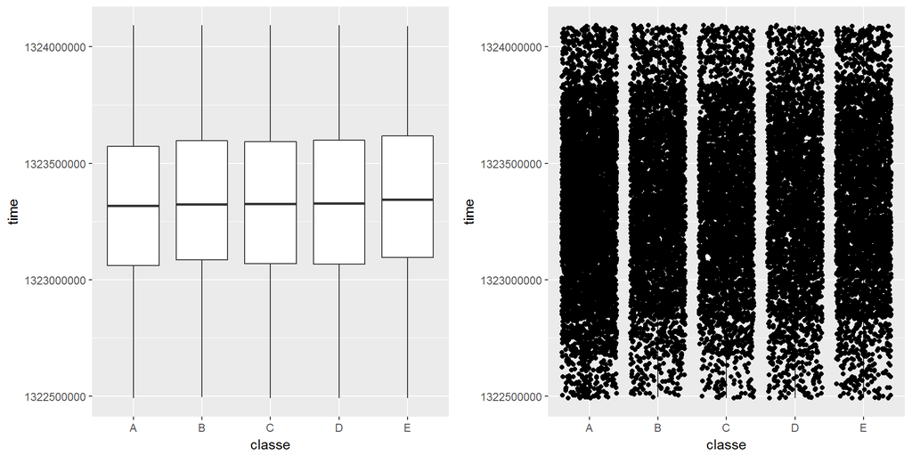

```r
eData <- training[,c(3,4,160)]
eData$time <- eData$raw_timestamp_part_1 + eData$raw_timestamp_part_2
expPlot <- ggplot(data=eData)+geom_boxplot(aes(x=classe,y=time))
grid.arrange(expPlot,expPlot + geom_jitter(aes(x=classe,y=time)),ncol=2,nrow=1)
```

```r
trainData <- training[,-naIdx]
trainData <- trainData[trainData$new_window=="no",]
trainData <- subset(trainData,select=-c(X,raw_timestamp_part_1,raw_timestamp_part_2,cvtd_timestamp,new_window))
```

The `trainData` is further filtered to use only observations with `no` as `new_window` value for this study. `X` (*index running number*) and 3 other time-related variables are omitted from `trainData` since these information are not useful for this study.

## Features selection

```r
length(names(trainData))
```

```
## [1] 55
```

Although `trainData` has been subsetted by removing unnecessary variables, the number of features is still quite large. Hence, features selection process is performed on `trainData`, using [chi-squared filter](https://rdrr.io/cran/FSelector/man/chi.squared.html).

From the selection result, variables with attribute importance more than 0.3 are selected for further analysis. Selected variables are as follow:

```r
fsRes <- chi.squared(classe~.,data=trainData)
selIdx <- which(fsRes$attr_importance > 0.3)
selIdx <- names(trainData)[selIdx]
selIdx <- c(selIdx,"classe")
selIdx
```

```
##  [1] "num_window"        "roll_belt"         "pitch_belt"
##  [4] "yaw_belt"          "total_accel_belt"  "gyros_belt_z"
##  [7] "accel_belt_z"      "magnet_belt_y"     "magnet_belt_z"
## [10] "roll_dumbbell"     "yaw_dumbbell"      "accel_dumbbell_x"
## [13] "accel_dumbbell_z"  "magnet_dumbbell_x" "magnet_dumbbell_y"
## [16] "magnet_dumbbell_z" "roll_forearm"      "pitch_forearm"
## [19] "classe"
```

## Model fitting

For model fitting, `randomForest` is used with default `ntree` of 500 for both following fits.

`fit1` is fitted using variables from subsetted dataset, while `fit2` is fitted using variables selected from chi-squared filter on subsetted dataset.

```r
set.seed(1)
fit1 <- randomForest(classe~.,data=trainData)
fit1
```

```
##
## Call:
##  randomForest(formula = classe ~ ., data = trainData)
##                Type of random forest: classification
##                      Number of trees: 500
## No. of variables tried at each split: 7
##
##         OOB estimate of  error rate: 0.15%
## Confusion matrix:
##      A    B    C    D    E  class.error
## A 5470    0    0    0    1 0.0001827819
## B    4 3712    2    0    0 0.0016137708
## C    0    5 3347    0    0 0.0014916468
## D    0    0   14 3132    1 0.0047664442
## E    0    0    0    1 3527 0.0002834467
```

```r
set.seed(1)
fit2 <- randomForest(classe~.,data=trainData[,selIdx])
fit2
```

```
##
## Call:
##  randomForest(formula = classe ~ ., data = trainData[, selIdx])
##                Type of random forest: classification
##                      Number of trees: 500
## No. of variables tried at each split: 4
##
##         OOB estimate of  error rate: 0.1%
## Confusion matrix:
##      A    B    C    D    E  class.error
## A 5470    0    0    1    0 0.0001827819
## B    2 3715    0    1    0 0.0008068854
## C    0    4 3348    0    0 0.0011933174
## D    0    0    6 3139    2 0.0025421036
## E    0    0    0    4 3524 0.0011337868
```

The concept of [out-of-bag error rate](https://en.wikipedia.org/wiki/Out-of-bag_error) (OOB) in `randomForest` model is similar to cross-validation. Hence, using OOB error rate to assess model performance, we can observe that using selected variables slightly improve OOB error rate of the fitted `randomForest` model.

Finally, the expected out-of-sample error of our selected model `fit2` would be the OOB error rate of the model, **0.1%**.

## Testing

Both fitted models are used to test against `testing` data, which show same prediction results for these 20 use cases. This is not surprising since these 2 models are not significantly different in term of OOB error rates.

```r
predict(fit1,newdata = testing)
```

```
##  1  2  3  4  5  6  7  8  9 10 11 12 13 14 15 16 17 18 19 20
##  B  A  B  A  A  E  D  B  A  A  B  C  B  A  E  E  A  B  B  B
## Levels: A B C D E
```

```r
predict(fit2,newdata = testing)
```

```
##  1  2  3  4  5  6  7  8  9 10 11 12 13 14 15 16 17 18 19 20
##  B  A  B  A  A  E  D  B  A  A  B  C  B  A  E  E  A  B  B  B
## Levels: A B C D E
```

## Reference

1. Velloso, E.; Bulling, A.; Gellersen, H.; Ugulino, W.; Fuks, H. [Qualitative Activity Recognition of Weight Lifting Exercises](http://groupware.les.inf.puc-rio.br/work.jsf?p1=11201). Proceedings of 4th International Conference in Cooperation with SIGCHI (Augmented Human ’13) . Stuttgart, Germany: ACM SIGCHI, 2013.